# Human Psoriasis Proportion Analyses

Larry Chen

2023-01-05

```r
Sys.setenv(RETICULATE_PYTHON = "C:/Users/Ji Lab/AppData/Local/Programs/Python/Python310")
library(reticulate)
#library(Seurat, lib.loc = "C:/Users/Ji Lab/AppData/Local/R/alt_packages/Seurat 4.1")
library(Seurat)
library(SeuratObject)
library(patchwork)
library(dplyr)
library(ggplot2)
library(reshape2)
library(tibble)
library(sessioninfo)
```

```r
sessioninfo::session_info()%>%
  details::details(
    summary = 'Current session info',
    open    = TRUE
  )
```

**Current session info**

```r
─ Session info ───────────────────────────────────────────────────────────────
 setting  value
 version  R version 4.2.2 (2022-10-31 ucrt)
 os       Windows 10 x64 (build 22621)
 system   x86_64, mingw32
 ui       RTerm
 language (EN)
 collate  English_United States.utf8
 ctype    English_United States.utf8
 tz       America/New_York
 date     2023-01-05
 pandoc   2.19.2 @ C:/Program Files/RStudio/resources/app/bin/quarto/bin/tools/ (via rmarkdown)

─ Packages ───────────────────────────────────────────────────────────────────
 package          * version   date (UTC) lib source
 abind              1.4-5     2016-07-21 [1] CRAN (R 4.2.0)
 assertthat         0.2.1     2019-03-21 [1] CRAN (R 4.2.1)
 bslib              0.4.2     2022-12-16 [1] CRAN (R 4.2.2)
 cachem             1.0.6     2021-08-19 [1] CRAN (R 4.2.1)
 cli                3.4.1     2022-09-23 [1] CRAN (R 4.2.1)
 clipr              0.8.0     2022-02-22 [1] CRAN (R 4.2.1)
 cluster            2.1.4     2022-08-22 [2] CRAN (R 4.2.2)
 codetools          0.2-18    2020-11-04 [2] CRAN (R 4.2.2)
 colorspace         2.0-3     2022-02-21 [1] CRAN (R 4.2.1)
 cowplot            1.1.1     2020-12-30 [1] CRAN (R 4.2.1)
 data.table         1.14.6    2022-11-16 [1] CRAN (R 4.2.2)
 DBI                1.1.3     2022-06-18 [1] CRAN (R 4.2.1)
 deldir             1.0-6     2021-10-23 [1] CRAN (R 4.2.0)
 desc               1.4.2     2022-09-08 [1] CRAN (R 4.2.1)
 details            0.3.0     2022-03-27 [1] CRAN (R 4.2.2)
 digest             0.6.30    2022-10-18 [1] CRAN (R 4.2.1)
 dplyr            * 1.0.10    2022-09-01 [1] CRAN (R 4.2.1)
 ellipsis           0.3.2     2021-04-29 [1] CRAN (R 4.2.1)
 evaluate           0.19      2022-12-13 [1] CRAN (R 4.2.2)
 fansi              1.0.3     2022-03-24 [1] CRAN (R 4.2.1)
 fastmap            1.1.0     2021-01-25 [1] CRAN (R 4.2.1)
 fitdistrplus       1.1-8     2022-03-10 [1] CRAN (R 4.2.1)
 future             1.30.0    2022-12-16 [1] CRAN (R 4.2.2)
 future.apply       1.10.0    2022-11-05 [1] CRAN (R 4.2.2)
 generics           0.1.3     2022-07-05 [1] CRAN (R 4.2.1)
 ggplot2          * 3.4.0     2022-11-04 [1] CRAN (R 4.2.2)
 ggrepel            0.9.2     2022-11-06 [1] CRAN (R 4.2.2)
 ggridges           0.5.4     2022-09-26 [1] CRAN (R 4.2.1)
 globals            0.16.2    2022-11-21 [1] CRAN (R 4.2.2)
 glue               1.6.2     2022-02-24 [1] CRAN (R 4.2.1)
 goftest            1.2-3     2021-10-07 [1] CRAN (R 4.2.0)
 gridExtra          2.3       2017-09-09 [1] CRAN (R 4.2.1)
 gtable             0.3.1     2022-09-01 [1] CRAN (R 4.2.1)
 htmltools          0.5.4     2022-12-07 [1] CRAN (R 4.2.2)
 htmlwidgets        1.6.0     2022-12-15 [1] CRAN (R 4.2.2)
 httpuv             1.6.6     2022-09-08 [1] CRAN (R 4.2.2)
 httr               1.4.4     2022-08-17 [1] CRAN (R 4.2.1)
 ica                1.0-3     2022-07-08 [1] CRAN (R 4.2.1)
 igraph             1.3.5     2022-09-22 [1] CRAN (R 4.2.1)
 irlba              2.3.5.1   2022-10-03 [1] CRAN (R 4.2.2)
 jquerylib          0.1.4     2021-04-26 [1] CRAN (R 4.2.1)
 jsonlite           1.8.3     2022-10-21 [1] CRAN (R 4.2.2)
 KernSmooth         2.23-20   2021-05-03 [2] CRAN (R 4.2.2)
 knitr              1.41      2022-11-18 [1] CRAN (R 4.2.2)
 later              1.3.0     2021-08-18 [1] CRAN (R 4.2.1)
 lattice            0.20-45   2021-09-22 [2] CRAN (R 4.2.2)
 lazyeval           0.2.2     2019-03-15 [1] CRAN (R 4.2.1)
 leiden             0.4.3     2022-09-10 [1] CRAN (R 4.2.1)
 lifecycle          1.0.3     2022-10-07 [1] CRAN (R 4.2.1)
 listenv            0.9.0     2022-12-16 [1] CRAN (R 4.2.2)
 lmtest             0.9-40    2022-03-21 [1] CRAN (R 4.2.1)
 magrittr           2.0.3     2022-03-30 [1] CRAN (R 4.2.1)
 MASS               7.3-58.1  2022-08-03 [2] CRAN (R 4.2.2)
 Matrix             1.5-4     2022-11-14 [1] R-Forge (R 4.2.2)
 matrixStats        0.63.0    2022-11-18 [1] CRAN (R 4.2.2)
 mime               0.12      2021-09-28 [1] CRAN (R 4.2.0)
 miniUI             0.1.1.1   2018-05-18 [1] CRAN (R 4.2.1)
 munsell            0.5.0     2018-06-12 [1] CRAN (R 4.2.1)
 nlme               3.1-160   2022-10-10 [2] CRAN (R 4.2.2)
 parallelly         1.33.0    2022-12-14 [1] CRAN (R 4.2.2)
 patchwork        * 1.1.2     2022-08-19 [1] CRAN (R 4.2.1)
 pbapply            1.6-0     2022-11-16 [1] CRAN (R 4.2.1)
 pillar             1.8.1     2022-08-19 [1] CRAN (R 4.2.1)
 pkgconfig          2.0.3     2019-09-22 [1] CRAN (R 4.2.1)
 plotly             4.10.1    2022-11-07 [1] CRAN (R 4.2.2)
 plyr               1.8.8     2022-11-11 [1] CRAN (R 4.2.2)
 png                0.1-8     2022-11-29 [1] CRAN (R 4.2.2)
 polyclip           1.10-4    2022-10-20 [1] CRAN (R 4.2.1)
 progressr          0.12.0    2022-12-13 [1] CRAN (R 4.2.2)
 promises           1.2.0.1   2021-02-11 [1] CRAN (R 4.2.1)
 purrr              0.3.5     2022-10-06 [1] CRAN (R 4.2.1)
 R6                 2.5.1     2021-08-19 [1] CRAN (R 4.2.1)
 RANN               2.6.1     2019-01-08 [1] CRAN (R 4.2.1)
 RColorBrewer       1.1-3     2022-04-03 [1] CRAN (R 4.2.0)
 Rcpp               1.0.9     2022-07-08 [1] CRAN (R 4.2.1)
 RcppAnnoy          0.0.20    2022-10-27 [1] CRAN (R 4.2.2)
 reshape2         * 1.4.4     2020-04-09 [1] CRAN (R 4.2.1)
 reticulate       * 1.26-9000 2022-11-29 [1] Github (rstudio/reticulate@a1d7f7f)
 rlang              1.0.6     2022-09-24 [1] CRAN (R 4.2.1)
 rmarkdown          2.19      2022-12-15 [1] CRAN (R 4.2.2)
 ROCR               1.0-11    2020-05-02 [1] CRAN (R 4.2.1)
 rprojroot          2.0.3     2022-04-02 [1] CRAN (R 4.2.1)
 rstudioapi         0.14      2022-08-22 [1] CRAN (R 4.2.1)
 Rtsne              0.16      2022-04-17 [1] CRAN (R 4.2.1)
 sass               0.4.4     2022-11-24 [1] CRAN (R 4.2.2)
 scales             1.2.1     2022-08-20 [1] CRAN (R 4.2.1)
 scattermore        0.8       2022-02-14 [1] CRAN (R 4.2.1)
 sctransform        0.3.5     2022-09-21 [1] CRAN (R 4.2.2)
 sessioninfo      * 1.2.2     2021-12-06 [1] CRAN (R 4.2.1)
 Seurat           * 4.3.0     2022-11-18 [1] CRAN (R 4.2.2)
 SeuratObject     * 4.1.3     2022-11-07 [1] CRAN (R 4.2.2)
 shiny              1.7.4     2022-12-15 [1] CRAN (R 4.2.2)
 sp                 1.5-1     2022-11-07 [1] CRAN (R 4.2.2)
 spatstat.data      3.0-0     2022-10-21 [1] CRAN (R 4.2.2)
 spatstat.explore   3.0-5     2022-11-10 [1] CRAN (R 4.2.2)
 spatstat.geom      3.0-3     2022-10-25 [1] CRAN (R 4.2.2)
 spatstat.random    3.0-1     2022-11-03 [1] CRAN (R 4.2.2)
 spatstat.sparse    3.0-0     2022-10-21 [1] CRAN (R 4.2.2)
 spatstat.utils     3.0-1     2022-10-19 [1] CRAN (R 4.2.2)
 stringi            1.7.8     2022-07-11 [1] CRAN (R 4.2.1)
 stringr            1.5.0     2022-12-02 [1] CRAN (R 4.2.2)
 survival           3.4-0     2022-08-09 [2] CRAN (R 4.2.2)
 tensor             1.5       2012-05-05 [1] CRAN (R 4.2.0)
 tibble           * 3.1.8     2022-07-22 [1] CRAN (R 4.2.1)
 tidyr              1.2.1     2022-09-08 [1] CRAN (R 4.2.1)
 tidyselect         1.2.0     2022-10-10 [1] CRAN (R 4.2.1)
 utf8               1.2.2     2021-07-24 [1] CRAN (R 4.2.1)
 uwot               0.1.14    2022-08-22 [1] CRAN (R 4.2.1)
 vctrs              0.5.1     2022-11-16 [1] CRAN (R 4.2.2)
 viridisLite        0.4.1     2022-08-22 [1] CRAN (R 4.2.1)
 withr              2.5.0     2022-03-03 [1] CRAN (R 4.2.1)
 xfun               0.35      2022-11-16 [1] CRAN (R 4.2.2)
 xml2               1.3.3     2021-11-30 [1] CRAN (R 4.2.1)
 xtable             1.8-4     2019-04-21 [1] CRAN (R 4.2.1)
 yaml               2.3.6     2022-10-18 [1] CRAN (R 4.2.1)
 zoo                1.8-11    2022-09-17 [1] CRAN (R 4.2.2)

 [1] C:/Users/Ji Lab/AppData/Local/R/win-library/4.2
 [2] C:/Program Files/R/R-4.2.2/library

──────────────────────────────────────────────────────────────────────────────
```

## Read in needed objects and files

```r
cheng_ife_cyc_int_metadata = read.table("C:/Users/Ji Lab/Documents/JID manuscript/Psoriasis/hu/cheng_ife/cheng_ife_cyc_int/cheng_ife_cyc_int_metadata.txt")
cheng_ife_cyc_int = readRDS("C:/Users/Ji Lab/Documents/JID manuscript/Psoriasis/hu/cheng_ife/cheng_ife_cyc_int/cheng_ife_cyc_int.Rds")
cheng_ife = readRDS("C:/Users/Ji Lab/Documents/JID manuscript/Psoriasis/hu/cheng_ife/cheng_ife.Rds")
```

# 5: PROPORTION ANALYSIS

## Proportion of cycling cells that are basal/spinous

First, we generate a table of proportions of basal and spinous cells that are cycling, with each cell representing the proportion of cycling cells that are either basal or spinous, for each sample.

This is done by calculating the proportion of cells in res 0.1 clusters 0 (cycling spinous) and 1 (cycling basal) in each sample.

```r
# Proportion analysis
cyc_prop_table = prop.table(table(cheng_ife_cyc_int_metadata[,"integrated_snn_res.0.1"],cheng_ife_cyc_int_metadata[,"sample"]),margin=2)
rownames(cyc_prop_table) = c("Spinous","Basal")
```

```r
cyc_prop_table
```

```
##
##                abd4   br41epi   br53epi    p48epi    p49epi     pso14       s11
##   Spinous 0.7750000 0.6849015 0.7363344 0.6883910 0.4752155 0.4963768 0.6062992
##   Basal   0.2250000 0.3150985 0.2636656 0.3116090 0.5247845 0.5036232 0.3937008
##
##             scalp26   scalp32
##   Spinous 0.5768194 0.7679012
##   Basal   0.4231806 0.2320988
```

Here, we create a melted version of the table showing the proportion of cycling cells that are either spinous or basal, for each sample.

```r
cyc_prop_table_df = melt(cyc_prop_table)
colnames(cyc_prop_table_df) = c("Layer","Sample","Proportion")
cyc_prop_table_df$Condition = c(rep("Healthy",6),rep("Pso",6),rep("Healthy",6))
```

```r
cyc_prop_table_df
```

```
##      Layer  Sample Proportion Condition
## 1  Spinous    abd4  0.7750000   Healthy
## 2    Basal    abd4  0.2250000   Healthy
## 3  Spinous br41epi  0.6849015   Healthy
## 4    Basal br41epi  0.3150985   Healthy
## 5  Spinous br53epi  0.7363344   Healthy
## 6    Basal br53epi  0.2636656   Healthy
## 7  Spinous  p48epi  0.6883910       Pso
## 8    Basal  p48epi  0.3116090       Pso
## 9  Spinous  p49epi  0.4752155       Pso
## 10   Basal  p49epi  0.5247845       Pso
## 11 Spinous   pso14  0.4963768       Pso
## 12   Basal   pso14  0.5036232       Pso
## 13 Spinous     s11  0.6062992   Healthy
## 14   Basal     s11  0.3937008   Healthy
## 15 Spinous scalp26  0.5768194   Healthy
## 16   Basal scalp26  0.4231806   Healthy
## 17 Spinous scalp32  0.7679012   Healthy
## 18   Basal scalp32  0.2320988   Healthy
```

#### Saving Boxplots

This melted table is then used to generate box plots.

```r
setwd('C:/Users/Ji Lab/Documents/JID manuscript/Psoriasis/hu/')
cyc_prop_table_df_basal = subset(cyc_prop_table_df,Layer=="Basal")
g <- ggplot(cyc_prop_table_df_basal, aes(Condition, Proportion)) + geom_boxplot() +
      labs(x='Layer', y='Proportion Basal of Cycling Cells',title='Cycling Cell Analysis')
ggsave(plot=g,"cheng_ife_cyc_int_proportion_basal_boxplot.pdf",width = 5, height=5, dpi=300, useDingbats=F)

cyc_prop_table_df_spn = subset(cyc_prop_table_df,Layer=="Spinous")
g <- ggplot(cyc_prop_table_df_spn, aes(Condition, Proportion)) + geom_boxplot() +
  labs(x='Layer', y='Proportion Spinous of Cycling Cells',title='Cycling Cell Analysis')
ggsave(plot=g,"cheng_ife_cyc_int_proportion_spn_boxplot.pdf",width = 5, height=5, dpi=300, useDingbats=F)
```

## Proportion of basal/spinous cells that are cycling

The overall equation for calculating the proportion of Basal/Spinous cells that are cycling is as follows:

$$Proportion\,of\,Basal/Spinous\,Cells\,that\,are\,Cycling =
\dfrac{Cycling\,Basal/Spinous\,Cells}{All\,Basal/Spinous\,Cells}$$

Since we have already identified the basal and spinous cells that are cycling, what’s left to do is to identify non-cycling basal spinous cells.

## Identifying non-cycling basal and spinous cells

Here, we identify non-cycling basal and spinous cells within the cheng_ife dataset.

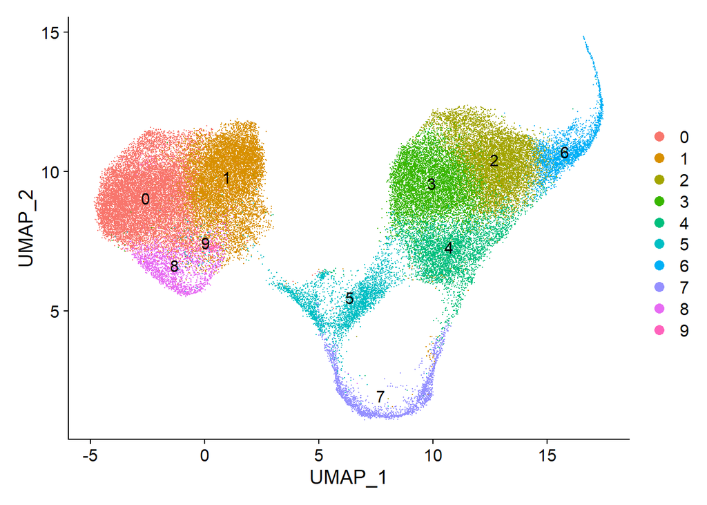

```r
Idents(cheng_ife) = "integrated_snn_res.0.4"
DimPlot(cheng_ife, reduction = "umap", label = TRUE)
```

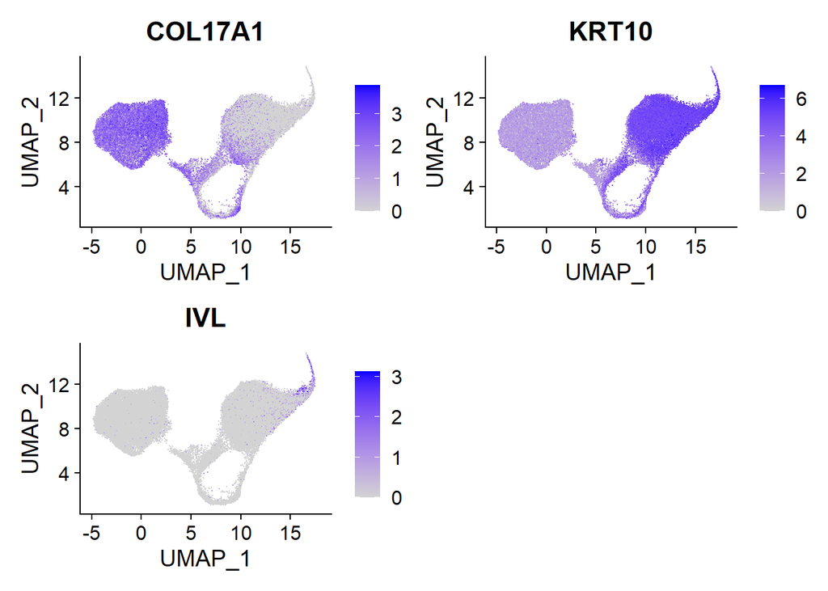

```r
DefaultAssay(cheng_ife) = "RNA"
FeaturePlot(cheng_ife, features = c("COL17A1", "KRT10", "IVL"))
```

```r
DefaultAssay(cheng_ife) = "integrated"
```

### Calculating proportions

We first create a table with the per sample proportions of basal, cycling, granular, and spinous cells.

```r
#FREQUENCY PROPORTION ANALYSIS
cheng_ife_metadata = read.csv("C:/Users/Ji Lab/Documents/JID manuscript/Psoriasis/hu/cheng_ife/cheng_ife_metadata.csv", row.names = 1)

#creating simple subpopulation annotations from integrated_snn_res.0.4 cluster identities
cheng_ife_metadata = cheng_ife_metadata %>% mutate(kc_subpop =
                     case_when(integrated_snn_res.0.4 %in% c(1,0,8,9) ~ "Basal",
                               integrated_snn_res.0.4 %in% c(2,3,4) ~ "Spinous",
                               integrated_snn_res.0.4 %in% c(5,7) ~ "Cycling",
                               integrated_snn_res.0.4 == 6 ~ "Granular")
)
prop.table(table(cheng_ife_metadata$kc_subpop, cheng_ife_metadata$sample), margin=2)
```

```
##
##                  abd4    br41epi    br53epi     p48epi     p49epi      pso14
##   Basal    0.59243243 0.50231481 0.27551388 0.58645054 0.46099594 0.50025954
##   Cycling  0.08648649 0.07556217 0.05607645 0.10203658 0.19833298 0.17908124
##   Granular 0.02135135 0.03753307 0.06851785 0.03740648 0.05278906 0.05580067
##   Spinous  0.29972973 0.38458995 0.59989181 0.27410640 0.28788203 0.26485855
##
##                   s11    scalp26    scalp32
##   Basal    0.41371841 0.49009116 0.38966310
##   Cycling  0.09169675 0.07352358 0.05479637
##   Granular 0.03682310 0.03567182 0.05682587
##   Spinous  0.45776173 0.40071344 0.49871465
```

We then reassign the cycling cells as either cycling spinous or cycling basal cells, by matching them to their cheng_ife_cyc_int integrated_snn_res.0.1 cluster identities.

```r
# Label cycling subpopulations from cheng_ife_cyc_int
kc_subpop_cyc = cheng_ife_metadata$kc_subpop
res0.1_clus = 0:1
res0.1_subpop = c("Spinous_Cycling","Basal_Cycling")
for (i in 1:2)
{
  clus_id = res0.1_clus[i]
  cell_id = rownames(cheng_ife_cyc_int_metadata)[which(cheng_ife_cyc_int_metadata[,"integrated_snn_res.0.1"]==clus_id)]
  print(length(cell_id))
  kc_subpop_cyc[match(cell_id,rownames(cheng_ife_metadata))] = res0.1_subpop[i]
}
```

```
## [1] 3352
## [1] 2078
```

```r
cheng_ife_metadata$kc_subpop_cyc = kc_subpop_cyc
```

We then classify cells as being from either psoriatic or healthy samples.

```r
# label condition
cheng_sample = c("pso14", "p48epi", "p49epi", "s11", "scalp26", "scalp32", "abd4",
                 "br41epi", "br53epi")
cheng_condition = c(rep("Pso",3),rep("Healthy",6))
cheng_sample_vector = cheng_ife_metadata$sample
for (i in 1:length(cheng_sample))
{
  clus_id = cheng_sample[i]
  cell_id = rownames(cheng_ife_metadata)[which(cheng_ife_metadata$sample==cheng_sample[i])]
  cheng_sample_vector[which(cheng_ife_metadata$sample==clus_id)] = cheng_condition[i]
}
```

####saving updated metadata

```r
setwd('C:/Users/Ji Lab/Documents/JID manuscript/Psoriasis/hu/cheng_ife')
cheng_ife_metadata$condition = cheng_sample_vector

write.table(cheng_ife_metadata,file="cheng_ife_metadata_cycling_subpopulation.txt",sep="\t",row.names=T,col.names=T)

ife_subpop_data = cheng_ife_metadata[,c("sample","kc_subpop_cyc","condition")]
```

####Calculations

Finally, we calculate the proportion of basal/spinous cells that are cycling, for each sample.

```r
# Calculate subpop proportions
subpop_table = table(cheng_ife_metadata$kc_subpop_cyc,cheng_ife_metadata$sample) #count table
pct_basal_cycling = apply(subpop_table, 2, function(x) {x[2]/(x[2]+x[1])})
pct_spinous_cycling = apply(subpop_table, 2, function(x) {x[5]/(x[5]+x[4])})

t.test(pct_basal_cycling[c(1:3,7:9)],pct_spinous_cycling[c(1:3,7:9)])
```

```
##
##  Welch Two Sample t-test
##
## data:  pct_basal_cycling[c(1:3, 7:9)] and pct_spinous_cycling[c(1:3, 7:9)]
## t = -3.1203, df = 6.8916, p-value = 0.01718
## alternative hypothesis: true difference in means is not equal to 0
## 95 percent confidence interval:
##  -0.1021018 -0.0139064
## sample estimates:
##  mean of x  mean of y
## 0.04992471 0.10792883
```

```r
t.test(pct_spinous_cycling[c(1:3,7:9)],pct_spinous_cycling[4:6])
```

```
##
##  Welch Two Sample t-test
##
## data:  pct_spinous_cycling[c(1:3, 7:9)] and pct_spinous_cycling[4:6]
## t = -5.5517, df = 6.2719, p-value = 0.001246
## alternative hypothesis: true difference in means is not equal to 0
## 95 percent confidence interval:
##  -0.18101557 -0.07106766
## sample estimates:
## mean of x mean of y
## 0.1079288 0.2339704
```

```r
ife_subpop_df = melt(ife_subpop_data)
```

### Saving boxplots

Showing proportion of basal/spinous cells that are cycling in each condition

```r
setwd('C:/Users/Ji Lab/Documents/JID manuscript/Psoriasis/hu/')
subpop_prop_table_df = data.frame(pct_basal_cycling,pct_spinous_cycling)
subpop_prop_table_df$condition = c(rep("Healthy",3),rep("Pso",3),rep("Healthy",3))
g <- ggplot(subpop_prop_table_df, aes(condition, pct_basal_cycling)) + geom_boxplot() +
  labs(x='Condition', y='Proportion Cycling Basal Cells',title='Cycling Cell Analysis')
ggsave(plot=g,"cheng_ife_cyc_int_basal_prop_cycling_boxplot.pdf",width = 5, height=5, dpi=300, useDingbats=F)

cyc_prop_table_df_spn = subset(cyc_prop_table_df,Layer=="Spinous")
g <- ggplot(subpop_prop_table_df, aes(condition, pct_spinous_cycling)) + geom_boxplot() +
  labs(x='Condition', y='Proportion Cycling Spinous Cells',title='Cycling Cell Analysis')
ggsave(plot=g,"cheng_ife_cyc_int_spn_prop_cycling_boxplot.pdf",width = 5, height=5, dpi=300, useDingbats=F)
```

## Final Results

```r
print(subpop_prop_table_df)
```

```
##         pct_basal_cycling pct_spinous_cycling condition
## abd4           0.03180212          0.18275608   Healthy
## br41epi        0.04525456          0.11860553   Healthy
## br53epi        0.05093168          0.06439820   Healthy
## p48epi         0.05142857          0.20398310       Pso
## p49epi         0.18419062          0.24664430       Pso
## pso14          0.15274725          0.25128393       Pso
## s11            0.08025682          0.10829817   Healthy
## scalp26        0.05969582          0.09570662   Healthy
## scalp32        0.03160726          0.07780836   Healthy
```